# Examen 2 de Modelos lineales

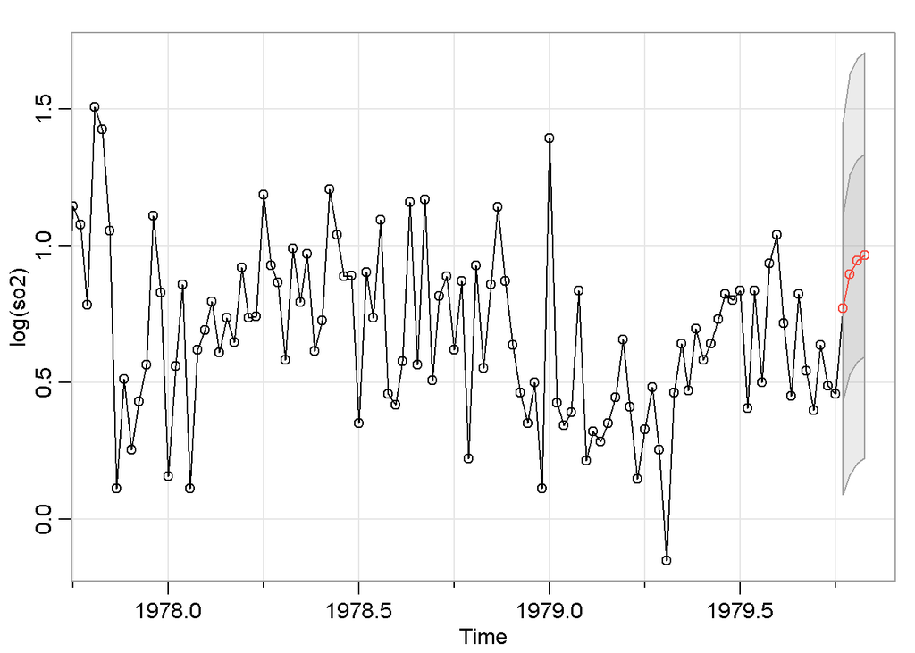

```
## $pred
## Time Series:
## Start = c(1979, 41)
## End = c(1979, 44)
## Frequency = 52
## [1] 0.7704985 0.8951897 0.9448517 0.9646312
##
## $se
## Time Series:
## Start = c(1979, 41)
## End = c(1979, 44)
## Frequency = 52
## [1] 0.3397939 0.3657526 0.3697029 0.3703257
```

```r
sarima.for(log(so2),4,1,0,0)
```

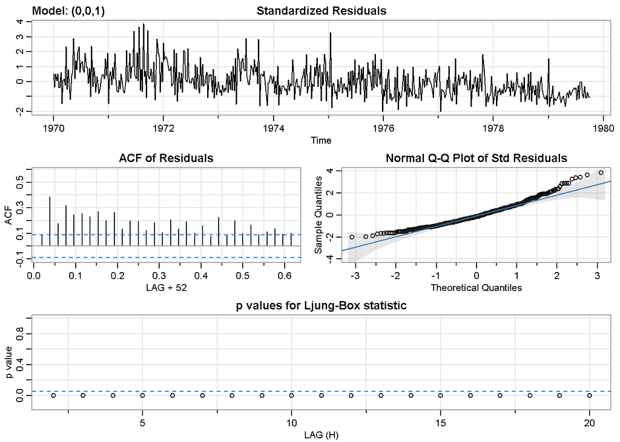

```
## $fit
##
## Call:
## arima(x = xdata, order = c(p, d, q), seasonal = list(order = c(P, D, Q), period = S),
##     xreg = xmean, include.mean = FALSE, transform.pars = trans, fixed = fixed,
##     optim.control = list(trace = trc, REPORT = 1, reltol = tol))
##
## Coefficients:
##          ma1   xmean
##       0.2306  2.8442
## s.e.  0.0335  0.0548
##
## sigma^2 estimated as 1.009:  log likelihood = -723.16,  aic = 1452.31
##
## $degrees_of_freedom
## [1] 506
##
## $ttable
##       Estimate     SE t.value p.value
## ma1     0.2306 0.0335  6.8776       0
## xmean   2.8442 0.0548 51.8755       0
##
## $AIC
## [1] 2.858884
##
## $AICc
## [1] 2.858931
##
## $BIC
## [1] 2.883867
```

```r
#MA--->acf
sarima(so2,0,0,1)
```

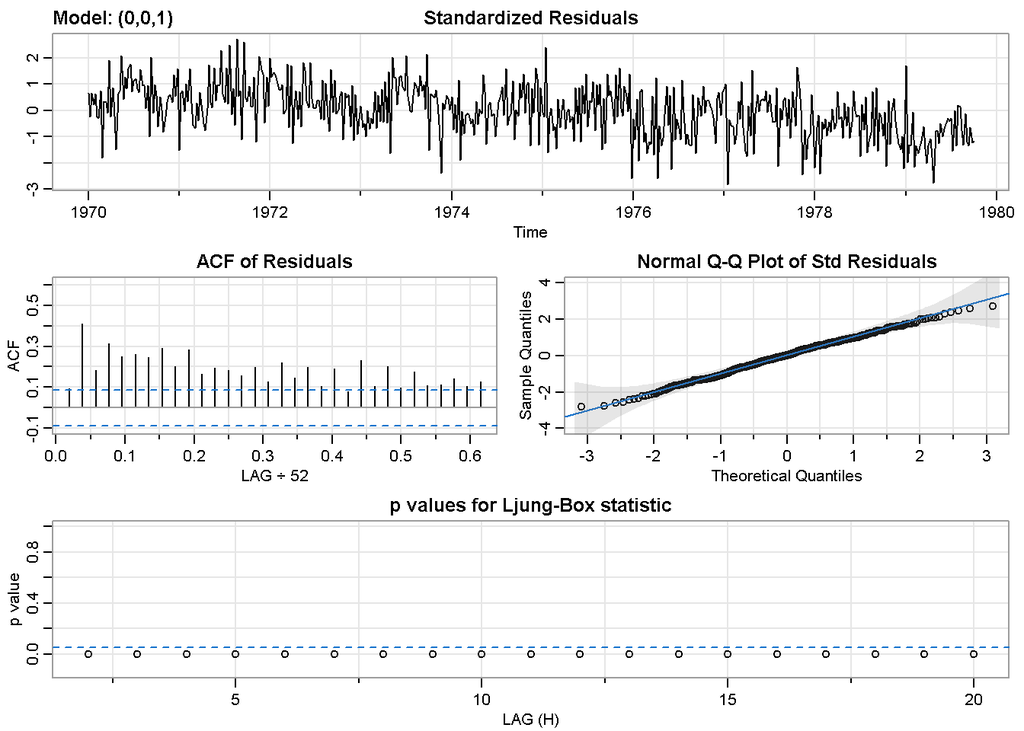

```
## $fit
##
## Call:
## arima(x = xdata, order = c(p, d, q), seasonal = list(order = c(P, D, Q), period = S),
##     xreg = xmean, include.mean = FALSE, transform.pars = trans, fixed = fixed,
##     optim.control = list(trace = trc, REPORT = 1, reltol = tol))
##
## Coefficients:
##          ma1   xmean
##       0.2421  0.9781
## s.e.  0.0332  0.0194
##
## sigma^2 estimated as 0.1244:  log likelihood = -191.38,  aic = 388.76
##
## $degrees_of_freedom
## [1] 506
##
## $ttable
##       Estimate     SE t.value p.value
## ma1     0.2421 0.0332  7.3018       0
## xmean   0.9781 0.0194 50.3434       0
##
## $AIC
## [1] 0.7652676
##
## $AICc
## [1] 0.7653144
##
## $BIC
## [1] 0.7902508
```

```r
sarima(log(so2),0,0,1)
```

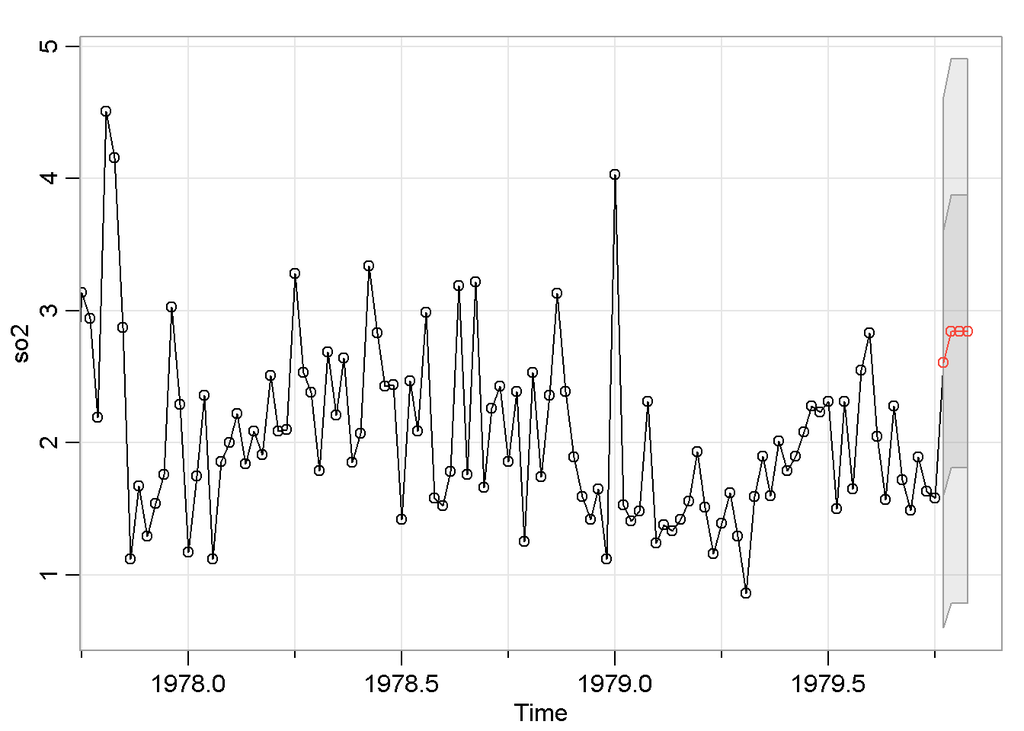

```
## $pred
## Time Series:
## Start = c(1979, 41)
## End = c(1979, 44)
## Frequency = 52
## [1] 2.608705 2.844241 2.844241 2.844241
##
## $se
## Time Series:
## Start = c(1979, 41)
## End = c(1979, 44)
## Frequency = 52
## [1] 1.004555 1.030922 1.030922 1.030922
```

```r
sarima.for(so2,4,0,0,1)
```

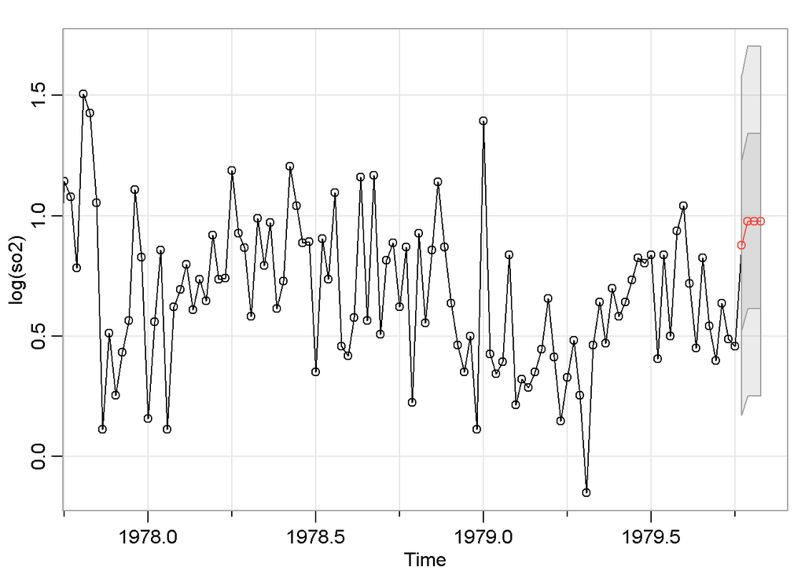

```
## $pred
## Time Series:
## Start = c(1979, 41)
## End = c(1979, 44)
## Frequency = 52
## [1] 0.8774778 0.9780547 0.9780547 0.9780547
##
## $se
## Time Series:
## Start = c(1979, 41)
## End = c(1979, 44)
## Frequency = 52
## [1] 0.3526534 0.3628443 0.3628443 0.3628443
```

```r
sarima.for(log(so2),4,0,0,1)
```

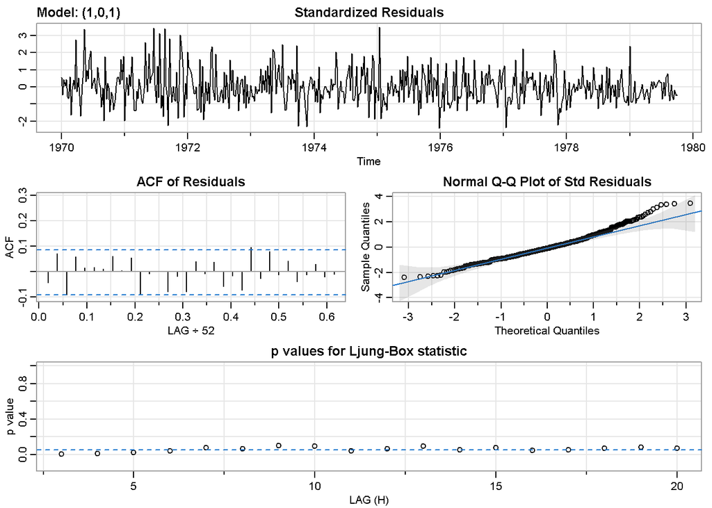

```
## $fit
##
## Call:
## arima(x = xdata, order = c(p, d, q), seasonal = list(order = c(P, D, Q), period = S),
##     xreg = xmean, include.mean = FALSE, transform.pars = trans, fixed = fixed,
##     optim.control = list(trace = trc, REPORT = 1, reltol = tol))
##
## Coefficients:
##          ar1      ma1   xmean
##       0.9696  -0.8096  2.7999
## s.e.  0.0144   0.0342  0.2332
##
## sigma^2 estimated as 0.7748:  log likelihood = -656.4,  aic = 1320.8
##
## $degrees_of_freedom
## [1] 505
##
## $ttable
##       Estimate     SE  t.value p.value
## ar1     0.9696 0.0144  67.4219       0
## ma1    -0.8096 0.0342 -23.6565       0
## xmean   2.7999 0.2332  12.0084       0
##
## $AIC
## [1] 2.600006
##
## $AICc
## [1] 2.600099
##
## $BIC
## [1] 2.633317
```

```r
#ARMA
sarima(so2,1,0,1)
```

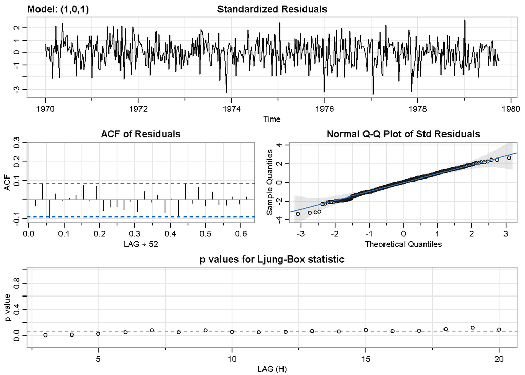

```
## $fit
##
## Call:
## arima(x = xdata, order = c(p, d, q), seasonal = list(order = c(P, D, Q), period = S),
##     xreg = xmean, include.mean = FALSE, transform.pars = trans, fixed = fixed,
##     optim.control = list(trace = trc, REPORT = 1, reltol = tol))
##
## Coefficients:
##          ar1      ma1   xmean
##       0.9712  -0.8069  0.9587
## s.e.  0.0141   0.0350  0.0870
##
## sigma^2 estimated as 0.09396:  log likelihood = -120.57,  aic = 249.14
##
## $degrees_of_freedom
## [1] 505
##
## $ttable
##       Estimate     SE  t.value p.value
## ar1     0.9712 0.0141  69.0824       0
## ma1    -0.8069 0.0350 -23.0691       0
## xmean   0.9587 0.0870  11.0253       0
##
## $AIC
## [1] 0.4904361
##
## $AICc
## [1] 0.4905298
##
## $BIC
## [1] 0.523747
```

```r
sarima(log(so2),1,0,1)
```

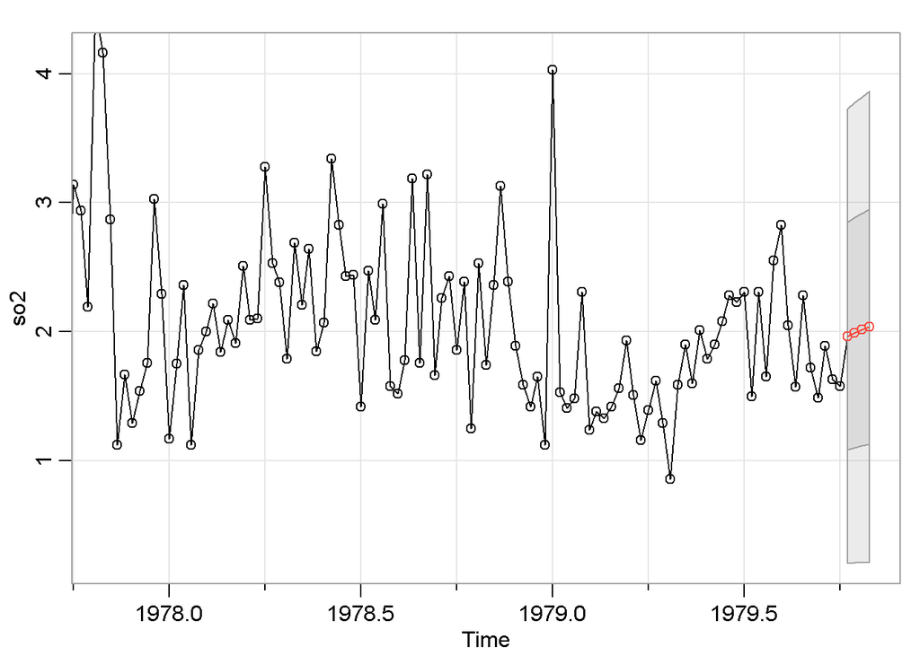

```
## $pred
## Time Series:
## Start = c(1979, 41)
## End = c(1979, 44)
## Frequency = 52
## [1] 1.966336 1.991691 2.016274 2.040109
##
## $se
## Time Series:
## Start = c(1979, 41)
## End = c(1979, 44)
## Frequency = 52
## [1] 0.8802022 0.8914011 0.9018021 0.9114718
```

```r
sarima.for(so2,4,1,0,1)
```

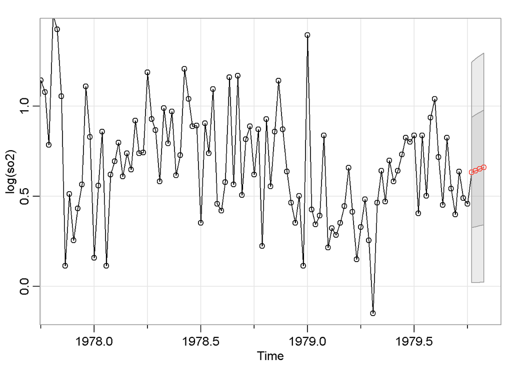

```
## $pred
## Time Series:
## Start = c(1979, 41)
## End = c(1979, 44)
## Frequency = 52
## [1] 0.6325068 0.6418917 0.6510066 0.6598592
##
## $se
## Time Series:
## Start = c(1979, 41)
## End = c(1979, 44)
## Frequency = 52
## [1] 0.3065295 0.3106385 0.3144653 0.3180329
```

```r
sarima.for(log(so2),4,1,0,1)
```

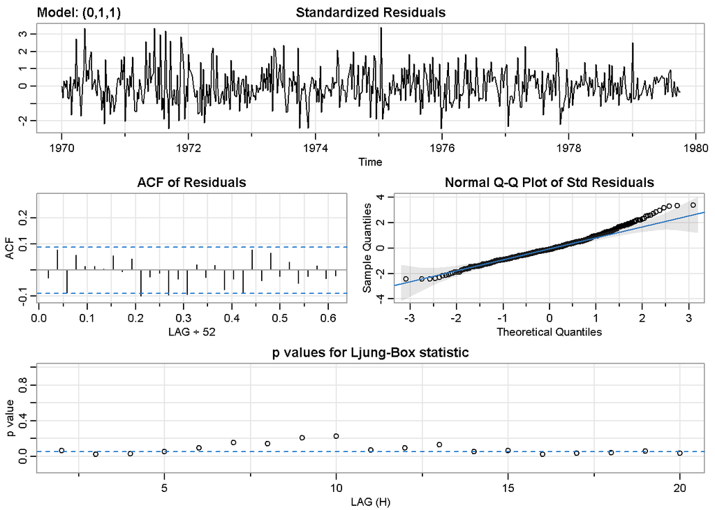

```r
#ARIMA
majo<-sarima(so2,0,1,1)
```

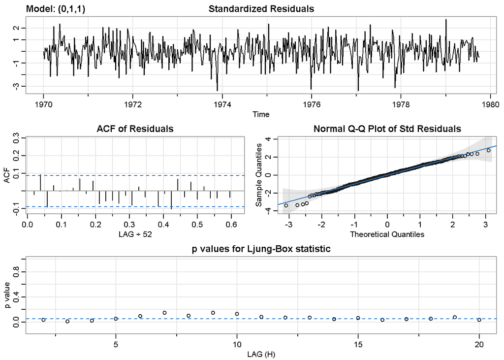

```r
majo1<-sarima(log(so2),0,1,1)
```

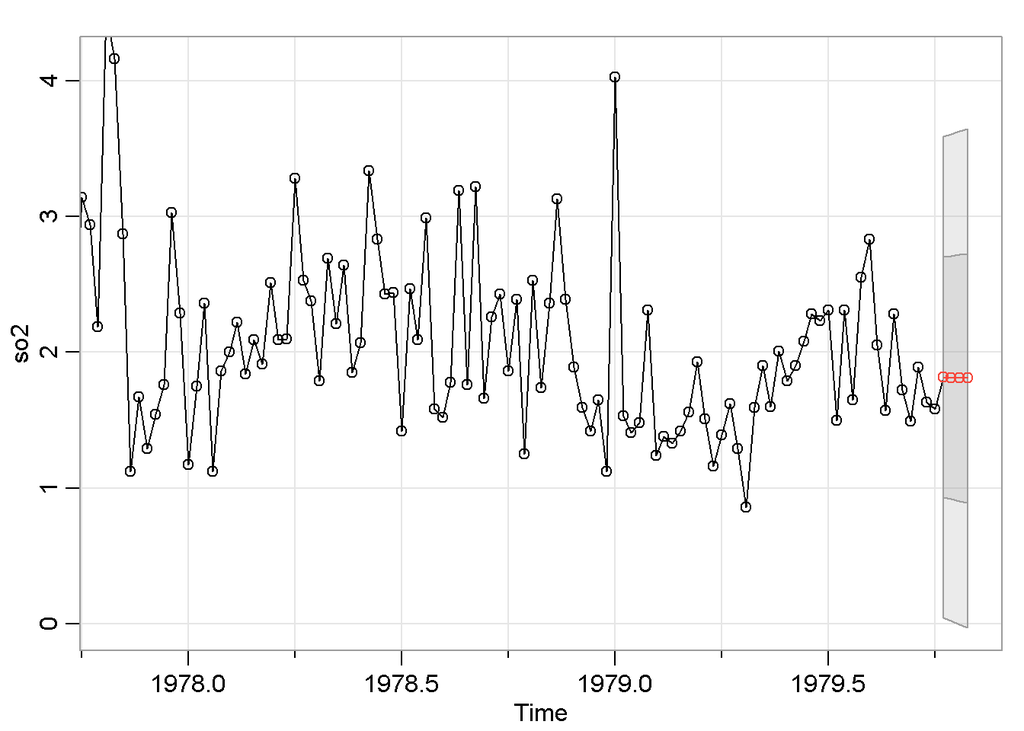

```r
pmajo<-sarima.for(so2,4,0,1,1)
```

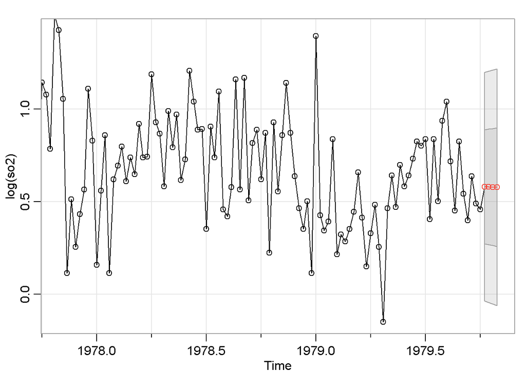

```r
pmajo1<-sarima.for(log(so2),4,0,1,1)
```

```r
majo1$fit
```

```
##
## Call:
## arima(x = xdata, order = c(p, d, q), seasonal = list(order = c(P, D, Q), period = S),
##     xreg = constant, transform.pars = trans, fixed = fixed, optim.control = list(trace = trc,
##         REPORT = 1, reltol = tol))
##
## Coefficients:
##           ma1  constant
##       -0.8374   -0.0010
## s.e.   0.0284    0.0022
##
## sigma^2 estimated as 0.09507:  log likelihood = -123.48,  aic = 252.96
```

```r
majo1$fit
```

```
##
## Call:
## arima(x = xdata, order = c(p, d, q), seasonal = list(order = c(P, D, Q), period = S),
##     xreg = constant, transform.pars = trans, fixed = fixed, optim.control = list(trace = trc,
##         REPORT = 1, reltol = tol))
##
## Coefficients:
##           ma1  constant
##       -0.8374   -0.0010
## s.e.   0.0284    0.0022
##
## sigma^2 estimated as 0.09507:  log likelihood = -123.48,  aic = 252.96
```

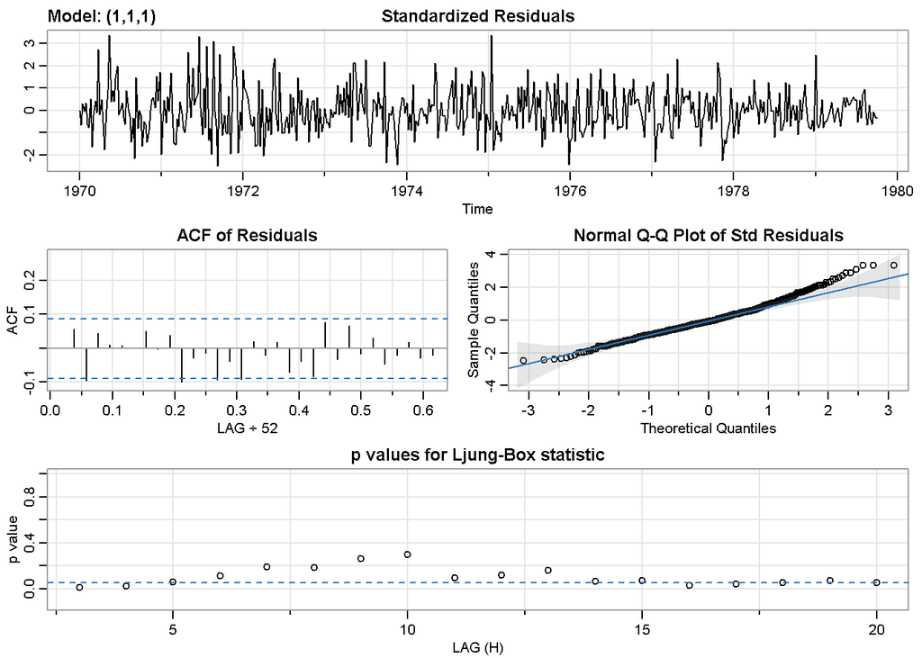

```r
#ARIMA
majoo<-sarima(so2,1,1,1)
```

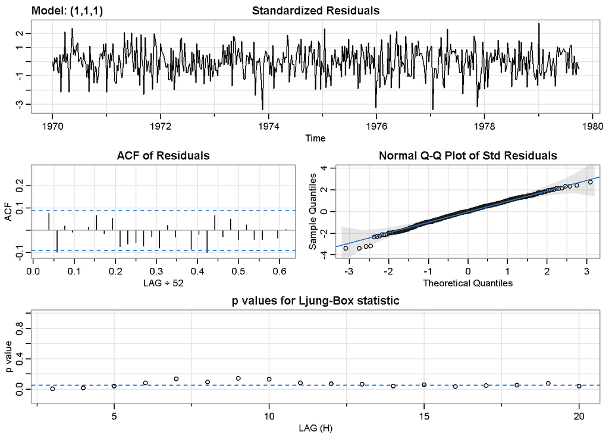

```r
majooo<-sarima(log(so2),1,1,1)
```

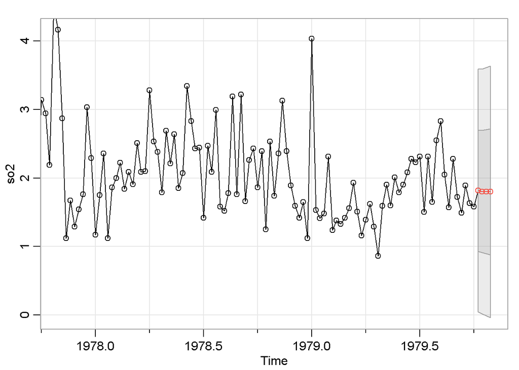

```
## $pred
## Time Series:
## Start = c(1979, 41)
## End = c(1979, 44)
## Frequency = 52
## [1] 1.816897 1.802658 1.800841 1.798409
##
## $se
## Time Series:
## Start = c(1979, 41)
## End = c(1979, 44)
## Frequency = 52
## [1] 0.8851636 0.8926083 0.9056487 0.9181917
```

```r
sarima.for(so2,4,1,1,1)
```

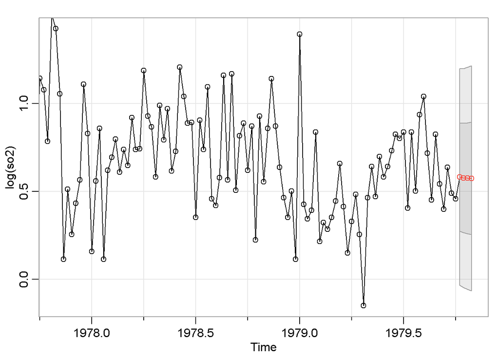

```
## $pred
## Time Series:
## Start = c(1979, 41)
## End = c(1979, 44)
## Frequency = 52
## [1] 0.5809154 0.5757013 0.5748392 0.5738300
##
## $se
## Time Series:
## Start = c(1979, 41)
## End = c(1979, 44)
## Frequency = 52
## [1] 0.3082332 0.3113632 0.3158369 0.3201984
```

```r
sarima.for(log(so2),4,1,1,1)
```

```r
majoo$fit
```

```
##
## Call:
## arima(x = xdata, order = c(p, d, q), seasonal = list(order = c(P, D, Q), period = S),
##     xreg = constant, transform.pars = trans, fixed = fixed, optim.control = list(trace = trc,
##         REPORT = 1, reltol = tol))
##
## Coefficients:
##           ar1      ma1  constant
##       -0.0495  -0.8206   -0.0024
## s.e.   0.0566   0.0369    0.0068
##
## sigma^2 estimated as 0.7835:  log likelihood = -658.16,  aic = 1324.31
```

```r
majooo$fit
```

```
##
## Call:
## arima(x = xdata, order = c(p, d, q), seasonal = list(order = c(P, D, Q), period = S),
##     xreg = constant, transform.pars = trans, fixed = fixed, optim.control = list(trace = trc,
##         REPORT = 1, reltol = tol))
##
## Coefficients:
##           ar1      ma1  constant
##       -0.0338  -0.8233   -0.0010
## s.e.   0.0576   0.0381    0.0024
##
## sigma^2 estimated as 0.09501:  log likelihood = -123.31,  aic = 254.62
```

```r
#AIC MAS BAJO, MEJOR MODELO
```

```r
#sarima(so2,1,1,1)
#sarima(log(so2),1,1,1)
#sarima.for(so2,4,1,1,1)
#sarima.for(log(so2),4,1,1,1)
```

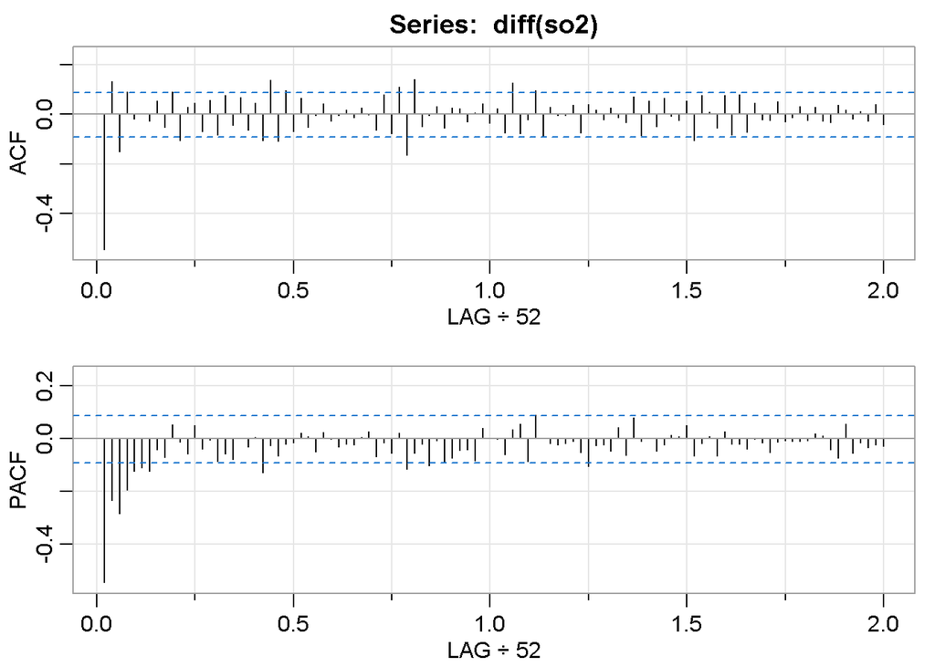

```
##       [,1]  [,2]  [,3]  [,4]  [,5]  [,6]  [,7]  [,8]  [,9] [,10] [,11] [,12]
## ACF  -0.54  0.13 -0.15  0.09 -0.02  0.00 -0.03  0.05 -0.05  0.09 -0.11  0.03
## PACF -0.54 -0.24 -0.28 -0.19 -0.12 -0.11 -0.12 -0.04 -0.07  0.05 -0.01 -0.06
##      [,13] [,14] [,15] [,16] [,17] [,18] [,19] [,20] [,21] [,22] [,23] [,24]
## ACF   0.05 -0.07  0.06 -0.08  0.08 -0.05  0.07 -0.06  0.04 -0.11  0.14 -0.11
## PACF  0.05 -0.04 -0.01 -0.09 -0.06 -0.08  0.00 -0.03  0.01 -0.13 -0.03 -0.06
##      [,25] [,26] [,27] [,28] [,29] [,30] [,31] [,32] [,33] [,34] [,35] [,36]
## ACF   0.10 -0.07  0.06 -0.05 -0.01  0.04 -0.03 -0.01  0.02 -0.01  0.03  0.00
## PACF -0.02 -0.01  0.02  0.01 -0.05  0.02  0.00 -0.03 -0.02 -0.02  0.01  0.03
##      [,37] [,38] [,39] [,40] [,41] [,42] [,43] [,44] [,45] [,46] [,47] [,48]
## ACF  -0.06  0.08 -0.08  0.11 -0.17  0.14 -0.05 -0.01  0.03 -0.06  0.03  0.02
## PACF -0.07 -0.02 -0.06  0.02 -0.11 -0.06 -0.02 -0.10 -0.01 -0.09 -0.07 -0.04
##      [,49] [,50] [,51] [,52] [,53] [,54] [,55] [,56] [,57] [,58] [,59] [,60]
## ACF  -0.03  0.01  0.04 -0.04  0.02 -0.07  0.13 -0.08 -0.02  0.10 -0.09  0.03
## PACF -0.04 -0.08  0.04  0.00  0.00 -0.06  0.04  0.06 -0.09  0.09  0.00 -0.02
##      [,61] [,62] [,63] [,64] [,65] [,66] [,67] [,68] [,69] [,70] [,71] [,72]
## ACF  -0.01 -0.01  0.04 -0.08  0.04  0.02 -0.02  0.03 -0.01 -0.03  0.07 -0.09
## PACF -0.02 -0.02 -0.01 -0.05 -0.10 -0.03 -0.02 -0.05  0.04 -0.06  0.08 -0.01
##      [,73] [,74] [,75] [,76] [,77] [,78] [,79] [,80] [,81] [,82] [,83] [,84]
## ACF   0.05 -0.05  0.06 -0.01 -0.02  0.05 -0.11  0.08  0.01 -0.06  0.08 -0.08
## PACF  0.00 -0.05 -0.02  0.01  0.01  0.05 -0.07 -0.02  0.01 -0.07  0.03 -0.02
##      [,85] [,86] [,87] [,88] [,89] [,90] [,91] [,92] [,93] [,94] [,95] [,96]
## ACF   0.08 -0.07  0.05 -0.02 -0.02  0.05 -0.03 -0.01  0.03 -0.02  0.03 -0.03
## PACF -0.02 -0.04  0.00 -0.02 -0.05 -0.01 -0.01 -0.01 -0.01 -0.01  0.02  0.01
##      [,97] [,98] [,99] [,100] [,101] [,102] [,103] [,104]
## ACF  -0.03  0.04  0.02  -0.02   0.01  -0.03   0.04  -0.04
## PACF -0.04 -0.07  0.06  -0.06  -0.01  -0.03  -0.02  -0.03
```

```r
acf2(diff(so2), max.lag=2*52)
```

3.35 Sea St los datos de ventas mensuales en ventas (n = 150), y sea Lt el indicador líder en adelanto.

1. Ajuste un modelo ARIMA a St , los datos de ventas mensuales. Analice el ajuste de su modelo paso a paso, presentando su (A) examen inicial de los datos, (B) transformaciones, si es necesario, (C) identificación inicial de los órdenes de dependencia y el grado de diferenciación, (D) parámetro estimación, (E) diagnóstico residual y elección del modelo.

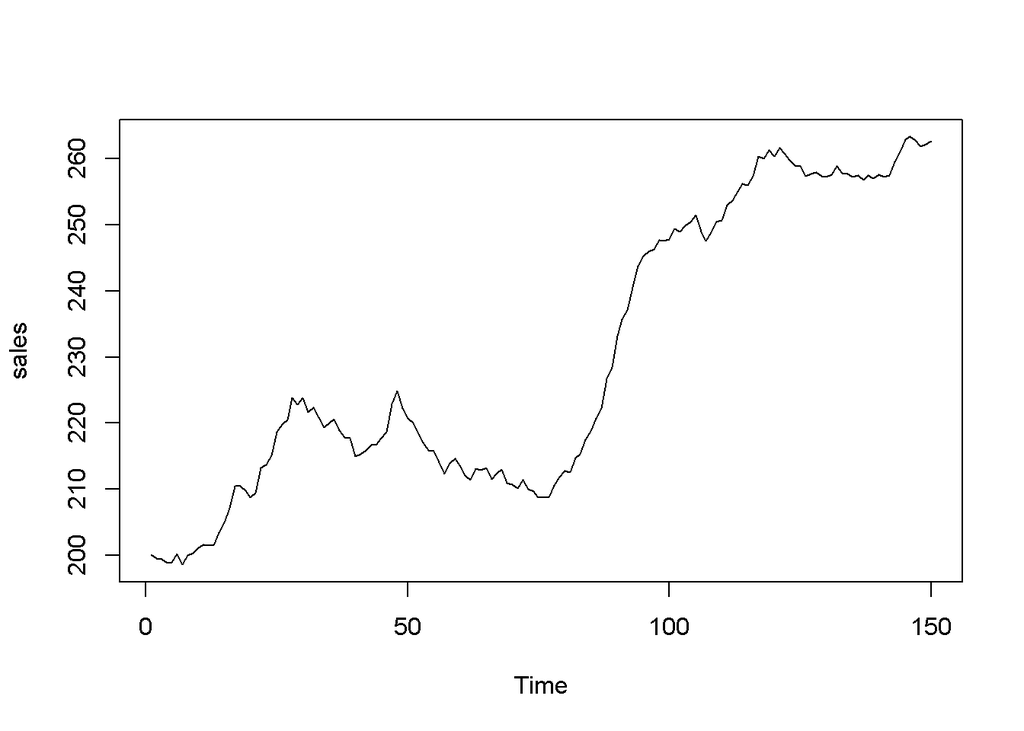

```r
plot(sales)
```

parece una caminata aleatoria, por lo que la diferencia d = 1, (puede hacer esto con log(sales) pero no es necesario).

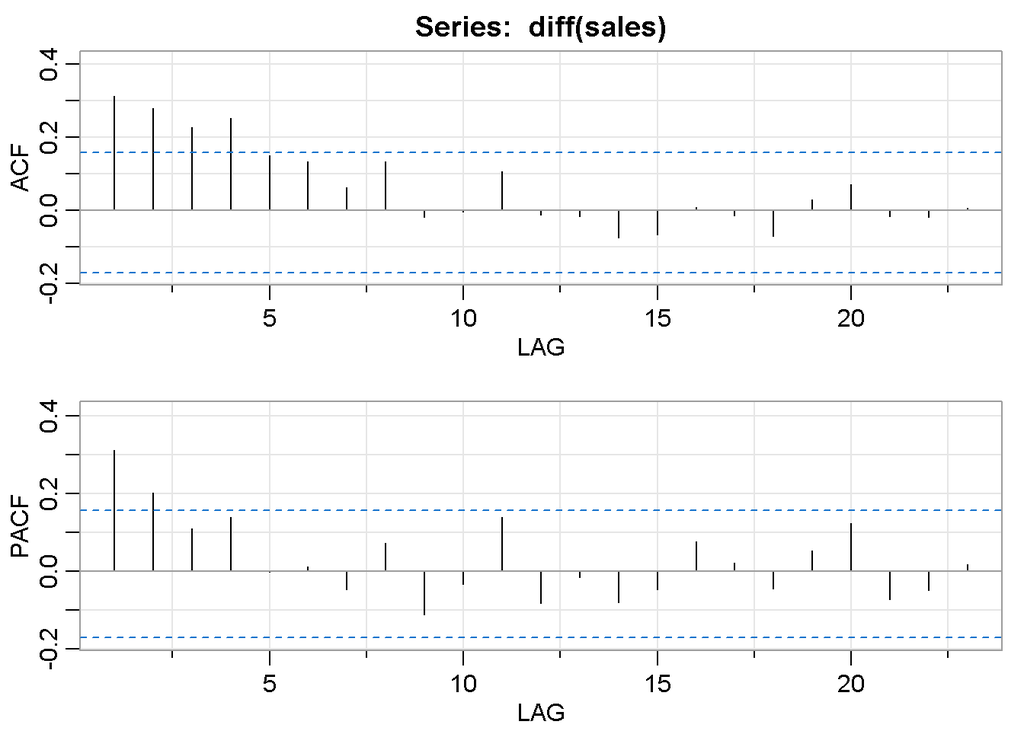

```
##      [,1] [,2] [,3] [,4] [,5] [,6]  [,7] [,8]  [,9] [,10] [,11] [,12] [,13]
## ACF  0.31 0.28 0.23 0.25 0.15 0.13  0.06 0.13 -0.02  0.00  0.11 -0.01 -0.02
## PACF 0.31 0.20 0.11 0.14 0.00 0.01 -0.05 0.07 -0.11 -0.03  0.14 -0.08 -0.02
##      [,14] [,15] [,16] [,17] [,18] [,19] [,20] [,21] [,22] [,23]
## ACF  -0.07 -0.07  0.01 -0.02 -0.07  0.03  0.07 -0.02 -0.02  0.01
## PACF -0.08 -0.05  0.08  0.02 -0.04  0.05  0.12 -0.07 -0.05  0.02
```

```r
acf2(diff(sales))
```

Tanto ACF como PACF siguen, así que elija p = q = 1

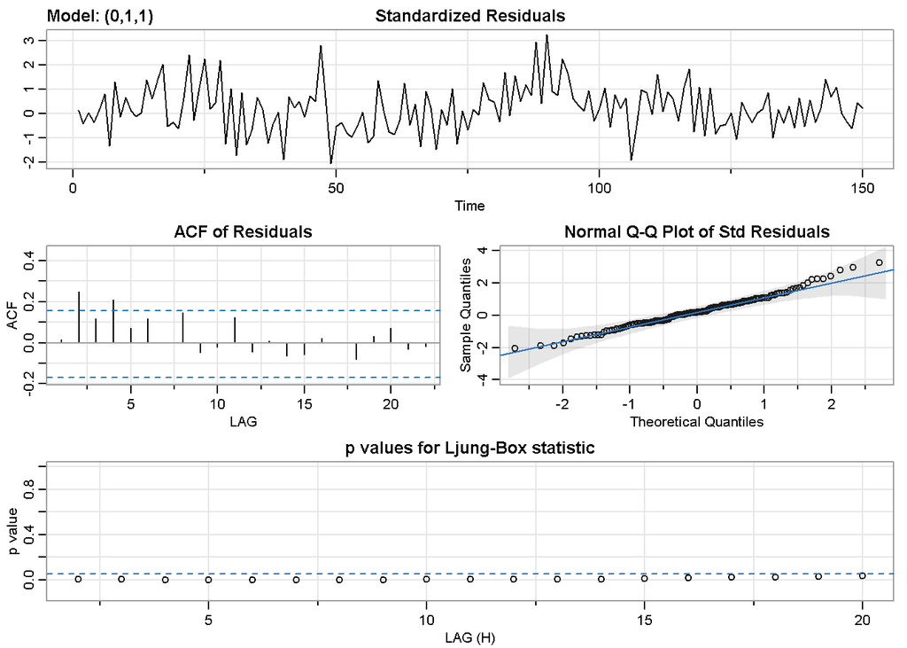

```
## $fit
##
## Call:
## arima(x = xdata, order = c(p, d, q), seasonal = list(order = c(P, D, Q), period = S),
##     include.mean = !no.constant, transform.pars = trans, fixed = fixed, optim.control = list(trace = trc,
##         REPORT = 1, reltol = tol))
##
## Coefficients:
##          ma1
##       0.2562
## s.e.  0.0653
##
## sigma^2 estimated as 2.042:  log likelihood = -264.63,  aic = 533.27
##
## $degrees_of_freedom
## [1] 148
##
## $ttable
##     Estimate     SE t.value p.value
## ma1   0.2562 0.0653  3.9232   1e-04
##
## $AIC
## [1] 3.578964
##
## $AICc
## [1] 3.579147
##
## $BIC
## [1] 3.619286
```

```r
sarima(sales,0,1,1, no.constant=TRUE)
```

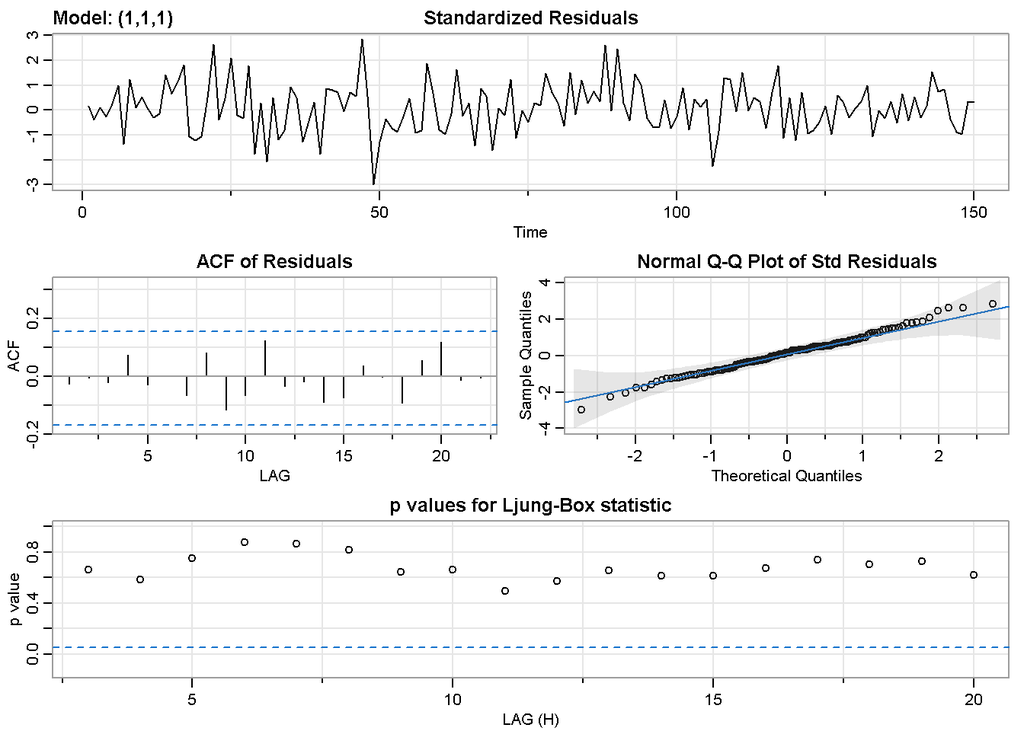

```
## $fit
##
## Call:
## arima(x = xdata, order = c(p, d, q), seasonal = list(order = c(P, D, Q), period = S),
##     include.mean = !no.constant, transform.pars = trans, fixed = fixed, optim.control = list(trace = trc,
##         REPORT = 1, reltol = tol))
##
## Coefficients:
##          ar1      ma1
##       0.8800  -0.6415
## s.e.  0.0644   0.1035
##
## sigma^2 estimated as 1.775:  log likelihood = -254.37,  aic = 514.74
##
## $degrees_of_freedom
## [1] 147
##
## $ttable
##     Estimate     SE t.value p.value
## ar1   0.8800 0.0644 13.6628       0
## ma1  -0.6415 0.1035 -6.1968       0
##
## $AIC
## [1] 3.454604
##
## $AICc
## [1] 3.455156
##
## $BIC
## [1] 3.515086
```

```r
sarima(sales,1,1,1, no.constant=TRUE)
```

Note que encaja bien, a direncia de un ARIMA(0,1,1)

2. Use el CCF y las gráficas de retardo entre $\triangledown S_t$ y $ L_t$ argumentar que una regresión de $\triangledown S_t$ en $\triangledown L_{t-3}$$ es razonable. [Tenga en cuenta que en lag2.plot(), la primera serie nombrada es la que se retrasa.]

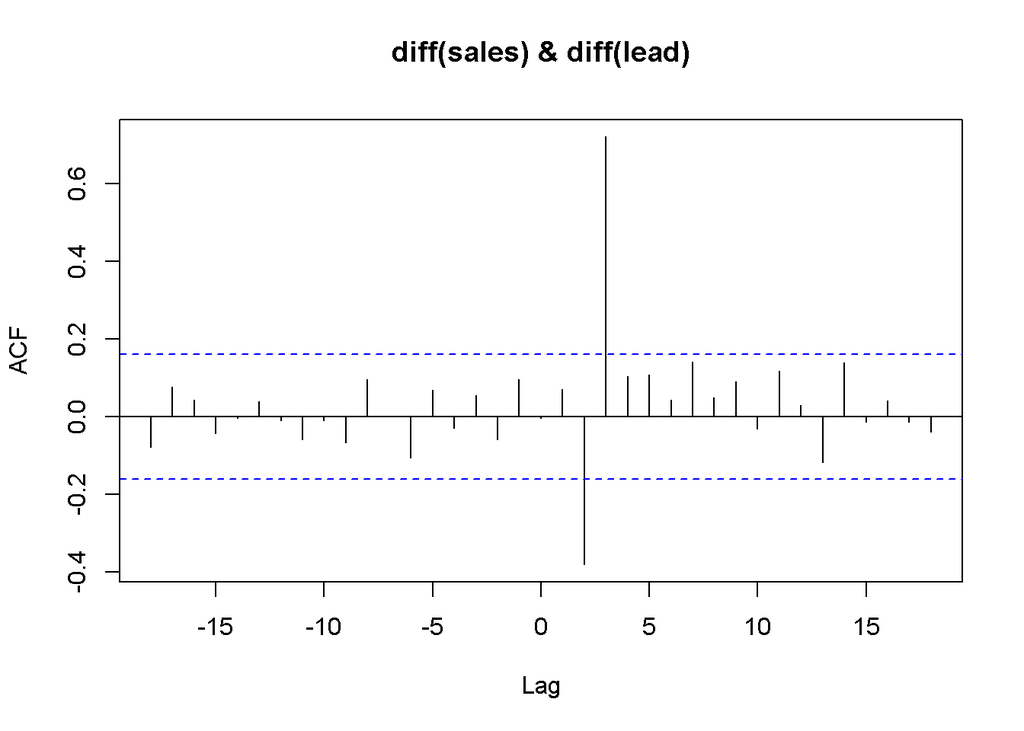

```r
data(sales)
data(lead)
ccf(diff(sales),diff(lead))
```

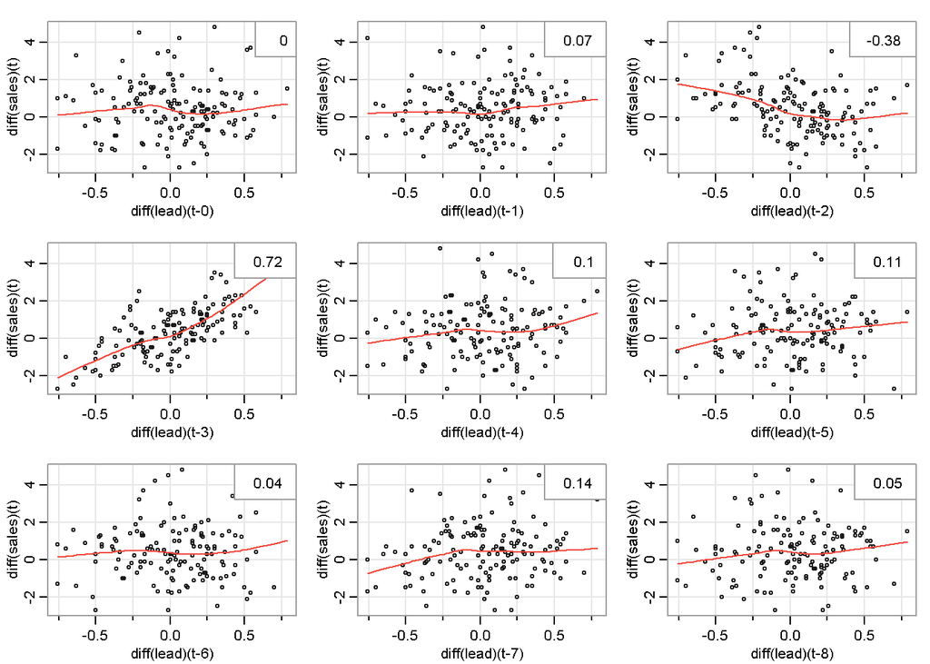

```r
lag2.plot(diff(lead), diff(sales),8)
```

ccf(diff(sales),diff(lead)) y lag2.plot(diff(lead), diff(sales),8) sugieren que existe una fuerte relación lineal entre diff(sales) y lag(diff(lead),-3).

```r
lag2.plot
```

[output not shown]

Tambien lag2.plot muestra una fuerte relación lineal.

3. Ajuste el modelo de regresión $\triangledown S_t= \beta _0 + \beta _1 \triangledown L_{t−3} + x_t$, donde $x_t$ es un proceso ARMA (explique cómo decidió su modelo para $x_t$). Discuta sus resultados. [Consulte el Ejemplo 3.45 para obtener ayuda sobre la codificación de este problema.]

Después de ajustar la regresión, ACF y PACF indican un AR(1) para los residuos, que se ajusta bien.

```r
u = ts.intersect(diff(sales), lag(diff(lead),-3))
ds = u[,1]
dl3 = u[,2]
(fit1 = lm(ds~dl3)) # beta1hat is highly significant
```

```
##
## Call:
## lm(formula = ds ~ dl3)
##
## Coefficients:
## (Intercept)          dl3
##      0.3554       3.3373
```

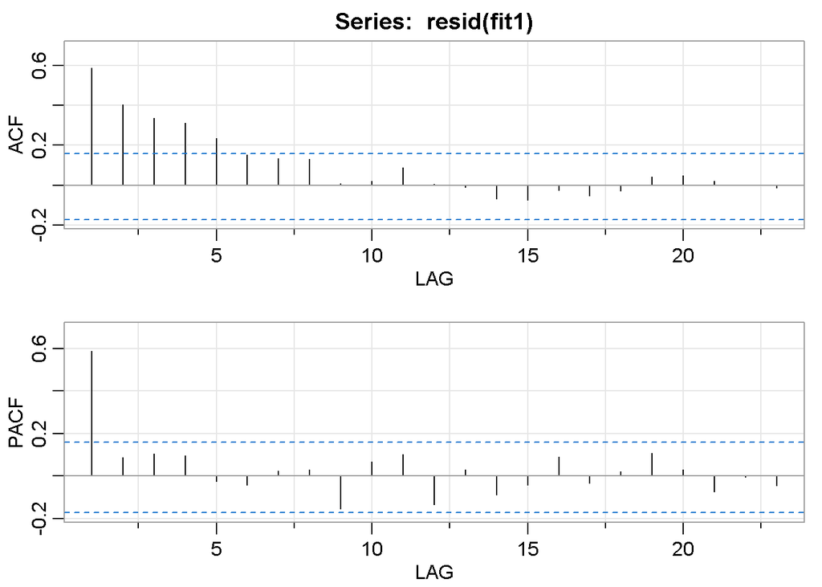

```
##      [,1] [,2] [,3] [,4]  [,5]  [,6] [,7] [,8]  [,9] [,10] [,11] [,12] [,13]
## ACF  0.59 0.40 0.34 0.31  0.23  0.15 0.13 0.13  0.01  0.02  0.09  0.01 -0.01
## PACF 0.59 0.09 0.11 0.10 -0.02 -0.04 0.03 0.03 -0.15  0.07  0.10 -0.13  0.03
##      [,14] [,15] [,16] [,17] [,18] [,19] [,20] [,21] [,22] [,23]
## ACF  -0.07 -0.07 -0.02 -0.05 -0.03  0.04  0.05  0.02  0.00 -0.01
## PACF -0.09 -0.04  0.09 -0.03  0.02  0.11  0.03 -0.07 -0.01 -0.04
```

```r
acf2(resid(fit1)) # => an AR(1) for the residuals
```

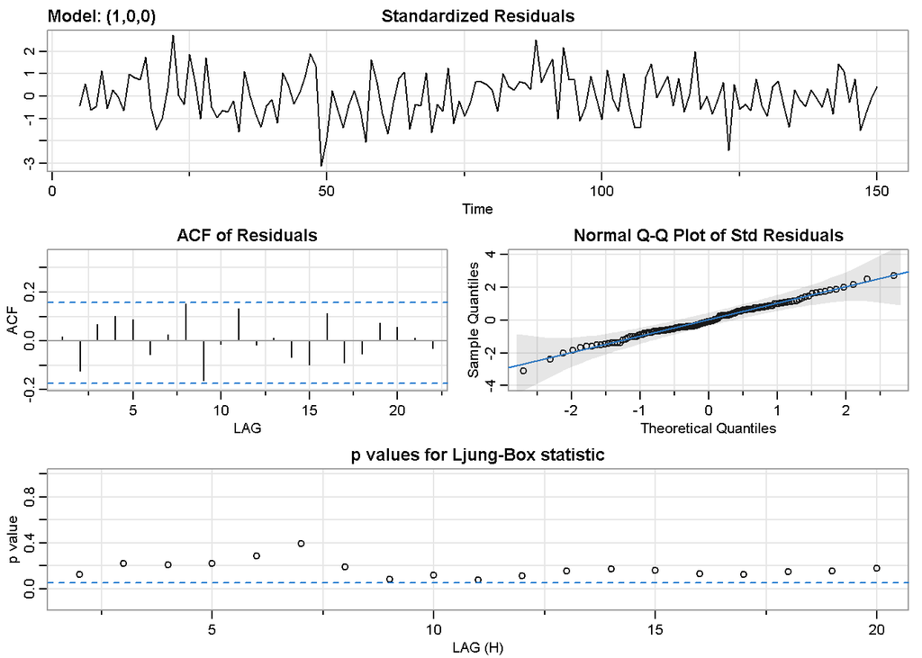

```
## $fit
##
## Call:
## stats::arima(x = xdata, order = c(p, d, q), seasonal = list(order = c(P, D,
##     Q), period = S), xreg = xreg, transform.pars = trans, fixed = fixed, optim.control = list(trace = trc,
##     REPORT = 1, reltol = tol))
##
## Coefficients:
##          ar1  intercept    xreg
##       0.6451     0.3624  2.7876
## s.e.  0.0628     0.1767  0.1432
##
## sigma^2 estimated as 0.5884:  log likelihood = -168.72,  aic = 345.43
##
## $degrees_of_freedom
## [1] 143
##
## $ttable
##           Estimate     SE t.value p.value
## ar1         0.6451 0.0628 10.2663  0.0000
## intercept   0.3624 0.1767  2.0509  0.0421
## xreg        2.7876 0.1432 19.4610  0.0000
##
## $AIC
## [1] 2.365981
##
## $AICc
## [1] 2.367139
##
## $BIC
## [1] 2.447724
```

```r
(fit2 = sarima(ds, 1,0,0, xreg=dl3)) # reg with ar1 errors
```

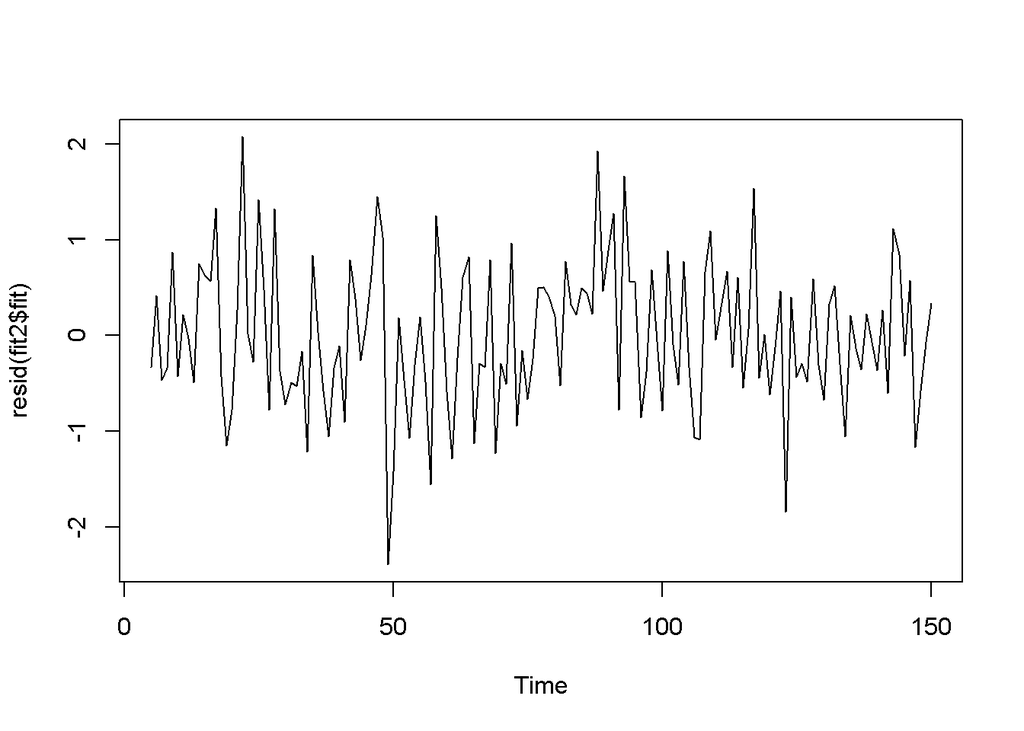

```r
plot(resid(fit2$fit))
```

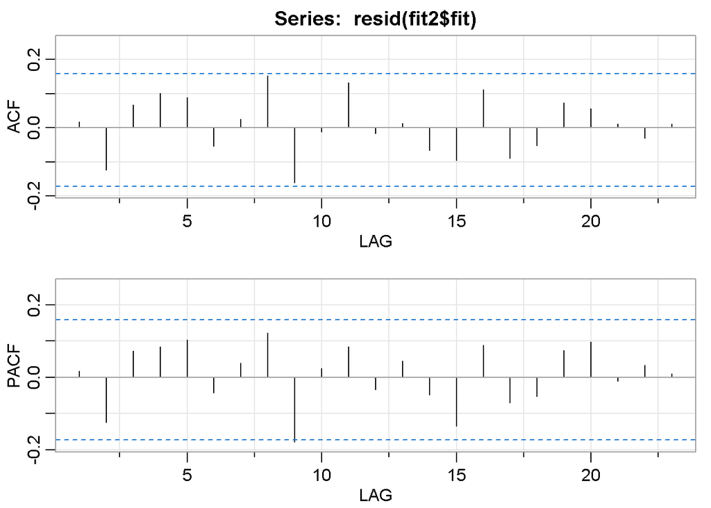

```
##      [,1]  [,2] [,3] [,4] [,5]  [,6] [,7] [,8]  [,9] [,10] [,11] [,12] [,13]
## ACF  0.02 -0.12 0.07 0.10 0.09 -0.05 0.03 0.15 -0.16 -0.01  0.13 -0.02  0.01
## PACF 0.02 -0.12 0.07 0.08 0.10 -0.04 0.04 0.12 -0.18  0.02  0.08 -0.03  0.05
##      [,14] [,15] [,16] [,17] [,18] [,19] [,20] [,21] [,22] [,23]
## ACF  -0.07 -0.10  0.11 -0.09 -0.05  0.07  0.06  0.01 -0.03  0.01
## PACF -0.05 -0.13  0.09 -0.07 -0.05  0.07  0.10 -0.01  0.03  0.01
```

```r
acf2(resid(fit2$fit))
```

3.42 Ajuste un modelo ARIMA estacional de su elección a los datos de desempleo en UnempRate. Utilice el modelo estimado para pronosticar los próximos 12 meses.

Este conjunto de datos es una actualización de unemp, pero en términos de porcentaje de desempleados. Las técnicas son las mismas que en el problema anterior y el modelo es casi el mismo; se necesita un parámetro MA adicional

```
#> ?unemp
```

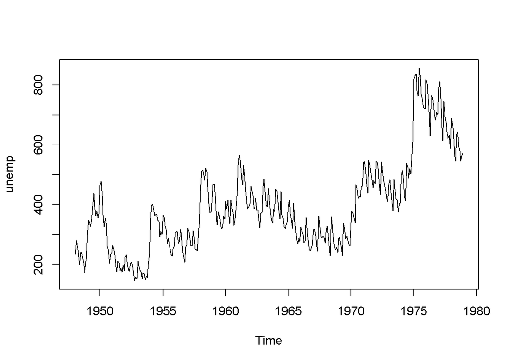

```r
#frequency(unemp)
data("unemp")
plot(unemp)
```

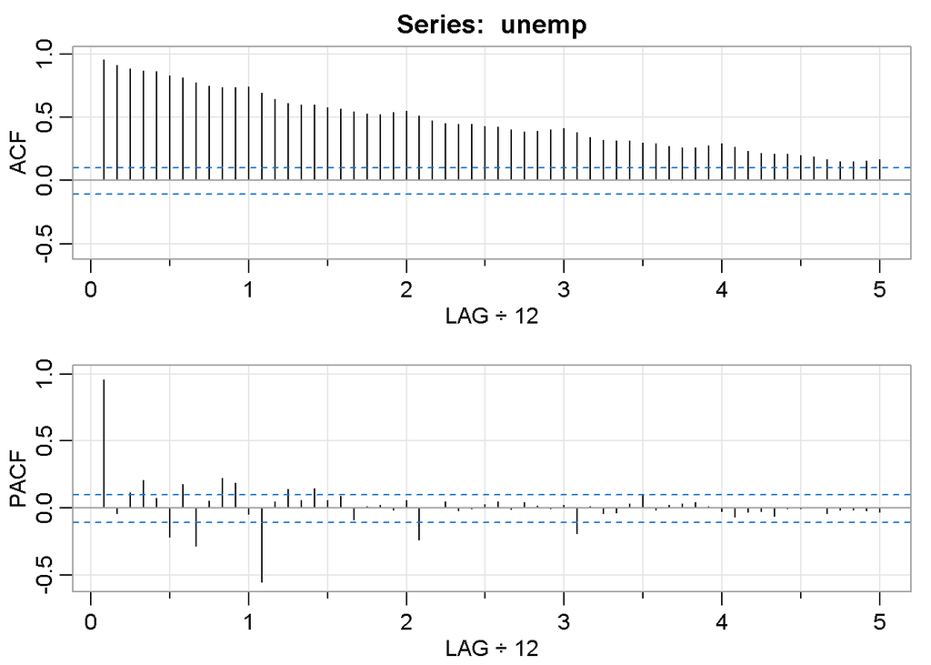

```
##      [,1]  [,2] [,3] [,4] [,5]  [,6] [,7]  [,8] [,9] [,10] [,11] [,12] [,13]
## ACF  0.96  0.92 0.88 0.87 0.86  0.83 0.81  0.78 0.75  0.73  0.74  0.74  0.69
## PACF 0.96 -0.04 0.12 0.21 0.07 -0.22 0.18 -0.28 0.05  0.22  0.19 -0.05 -0.55
##      [,14] [,15] [,16] [,17] [,18] [,19] [,20] [,21] [,22] [,23] [,24] [,25]
## ACF   0.64  0.61  0.60  0.60  0.58  0.57  0.54  0.53  0.53  0.54  0.55  0.51
## PACF  0.05  0.14  0.06  0.15  0.06  0.09 -0.09  0.01  0.02 -0.02  0.06 -0.24
##      [,26] [,27] [,28] [,29] [,30] [,31] [,32] [,33] [,34] [,35] [,36] [,37]
## ACF   0.48  0.45  0.45  0.45  0.43  0.42  0.40  0.39  0.39   0.4  0.42  0.38
## PACF  0.01  0.05 -0.02  0.00  0.03  0.05 -0.01  0.04  0.02   0.0  0.02 -0.19
##      [,38] [,39] [,40] [,41] [,42] [,43] [,44] [,45] [,46] [,47] [,48] [,49]
## ACF   0.34  0.32  0.31  0.31  0.30  0.29  0.27  0.26  0.26  0.28  0.29  0.26
## PACF  0.01 -0.04 -0.03  0.03  0.09 -0.01  0.02  0.03  0.04  0.01 -0.02 -0.07
##      [,50] [,51] [,52] [,53] [,54] [,55] [,56] [,57] [,58] [,59] [,60]
## ACF   0.23  0.21  0.21  0.21   0.2  0.19  0.17  0.15  0.15  0.16  0.17
## PACF -0.03 -0.02 -0.06  0.00   0.0  0.00 -0.04 -0.01 -0.01 -0.02 -0.03
```

```r
acf2(unemp,max.lag = 60)
```

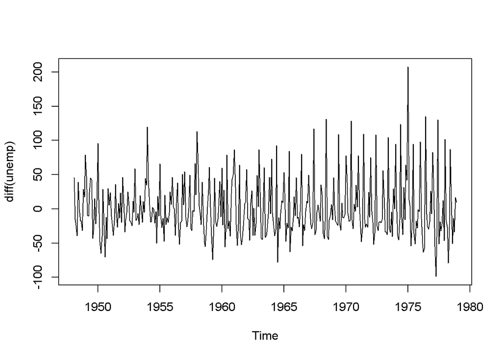

```r
plot(diff(unemp))
```

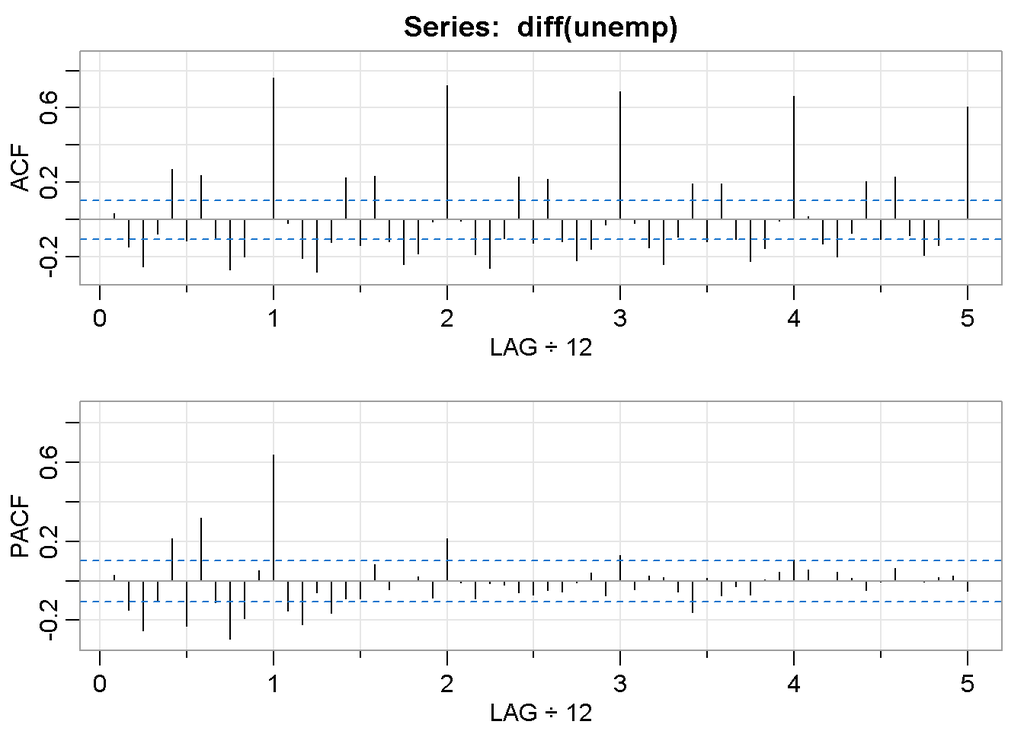

```
##      [,1]  [,2]  [,3]  [,4] [,5]  [,6] [,7]  [,8]  [,9] [,10] [,11] [,12] [,13]
## ACF  0.03 -0.15 -0.25 -0.08 0.27 -0.12 0.24 -0.11 -0.27 -0.20  0.00  0.76 -0.02
## PACF 0.03 -0.15 -0.25 -0.10 0.21 -0.23 0.32 -0.11 -0.30 -0.19  0.05  0.64 -0.15
##      [,14] [,15] [,16] [,17] [,18] [,19] [,20] [,21] [,22] [,23] [,24] [,25]
## ACF  -0.21 -0.28 -0.12  0.23 -0.14  0.23 -0.12 -0.24 -0.18 -0.01  0.72 -0.01
## PACF -0.22 -0.06 -0.16 -0.09 -0.09  0.08 -0.04  0.00  0.02 -0.09  0.21 -0.01
##      [,26] [,27] [,28] [,29] [,30] [,31] [,32] [,33] [,34] [,35] [,36] [,37]
## ACF  -0.19 -0.26 -0.10  0.23 -0.13  0.22 -0.12 -0.22 -0.16 -0.03  0.69 -0.02
## PACF -0.09 -0.01 -0.02 -0.06 -0.07 -0.05 -0.06 -0.01  0.04 -0.08  0.13 -0.04
##      [,38] [,39] [,40] [,41] [,42] [,43] [,44] [,45] [,46] [,47] [,48] [,49]
## ACF  -0.15 -0.24 -0.09  0.19 -0.12  0.19 -0.11 -0.23 -0.15 -0.01  0.66  0.01
## PACF  0.03  0.02 -0.06 -0.16  0.02 -0.08 -0.03 -0.07  0.01  0.05  0.10  0.06
##      [,50] [,51] [,52] [,53] [,54] [,55] [,56] [,57] [,58] [,59] [,60]
## ACF  -0.13 -0.20 -0.07  0.21 -0.11  0.23 -0.09 -0.19 -0.14  0.00  0.61
## PACF  0.00  0.04  0.01 -0.05 -0.01  0.06  0.00  0.00  0.02  0.02 -0.05
```

```r
acf2(diff(unemp),max.lag = 60)
```

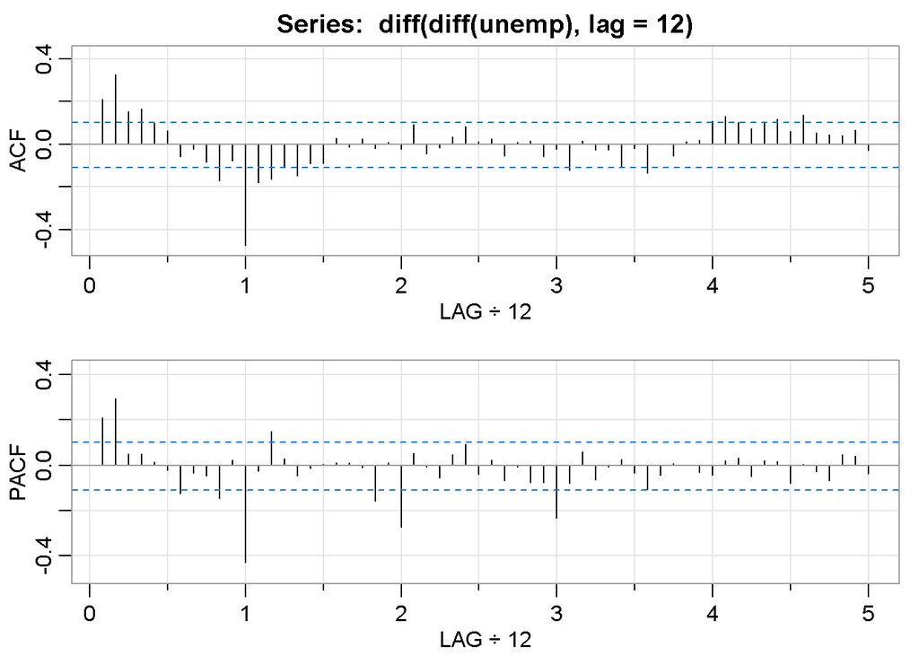

```
##      [,1] [,2] [,3] [,4] [,5]  [,6]  [,7]  [,8]  [,9] [,10] [,11] [,12] [,13]
## ACF  0.21 0.33 0.15 0.17 0.10  0.06 -0.06 -0.02 -0.09 -0.17 -0.08 -0.48 -0.18
## PACF 0.21 0.29 0.05 0.05 0.01 -0.02 -0.12 -0.03 -0.05 -0.15  0.02 -0.43 -0.02
##      [,14] [,15] [,16] [,17] [,18] [,19] [,20] [,21] [,22] [,23] [,24] [,25]
## ACF  -0.16 -0.11 -0.15 -0.09 -0.09  0.03 -0.01  0.02 -0.02  0.01 -0.02  0.09
## PACF  0.15  0.03 -0.04 -0.01  0.00  0.01  0.01 -0.01 -0.16  0.01 -0.27  0.05
##      [,26] [,27] [,28] [,29] [,30] [,31] [,32] [,33] [,34] [,35] [,36] [,37]
## ACF  -0.05 -0.01  0.03  0.08  0.01  0.03 -0.05  0.01  0.02 -0.06 -0.02 -0.12
## PACF -0.01 -0.05  0.05  0.09 -0.04  0.02 -0.07 -0.01 -0.08 -0.08 -0.23 -0.08
##      [,38] [,39] [,40] [,41] [,42] [,43] [,44] [,45] [,46] [,47] [,48] [,49]
## ACF   0.01 -0.03 -0.03 -0.10 -0.02 -0.13  0.00 -0.06  0.01  0.02  0.11  0.13
## PACF  0.06 -0.07 -0.01  0.03 -0.03 -0.11 -0.04  0.01  0.00 -0.03 -0.04  0.02
##      [,50] [,51] [,52] [,53] [,54] [,55] [,56] [,57] [,58] [,59] [,60]
## ACF   0.10  0.07  0.10  0.12  0.06  0.14  0.05  0.04  0.04  0.07 -0.03
## PACF  0.03 -0.05  0.02  0.02 -0.08  0.00 -0.03 -0.07  0.05  0.04 -0.04
```

```r
acf2(diff(diff(unemp),lag = 12), 60)
```

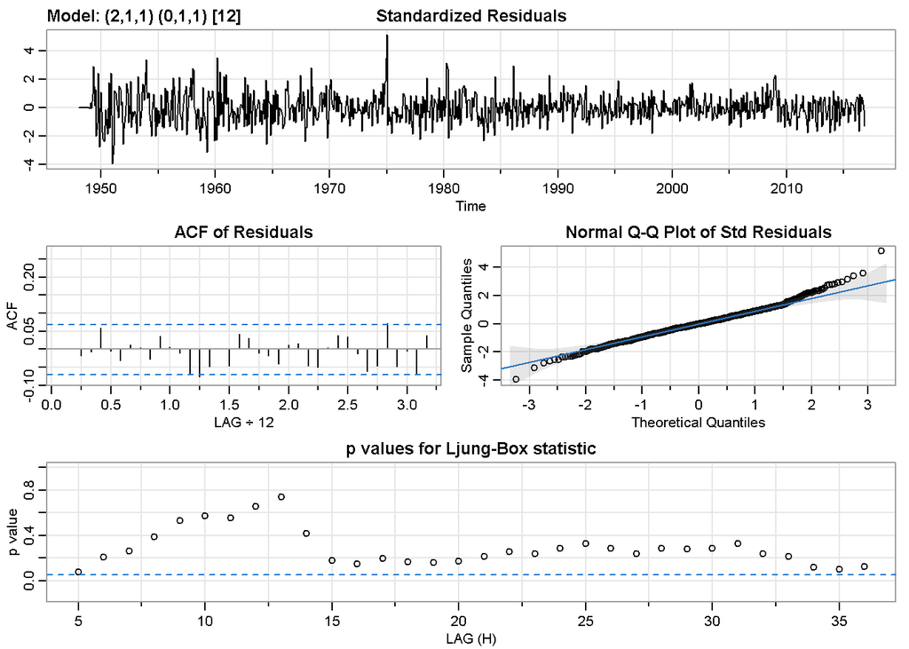

```
## $fit
##
## Call:
## arima(x = xdata, order = c(p, d, q), seasonal = list(order = c(P, D, Q), period = S),
##     include.mean = !no.constant, transform.pars = trans, fixed = fixed, optim.control = list(trace = trc,
##         REPORT = 1, reltol = tol))
##
## Coefficients:
##          ar1     ar2      ma1     sma1
##       0.5897  0.1342  -0.4831  -0.7676
## s.e.  0.1105  0.0465   0.1090   0.0254
##
## sigma^2 estimated as 0.05559:  log likelihood = 15.69,  aic = -21.38
##
## $degrees_of_freedom
## [1] 810
##
## $ttable
##      Estimate     SE  t.value p.value
## ar1    0.5897 0.1105   5.3353   0.000
## ar2    0.1342 0.0465   2.8826   0.004
## ma1   -0.4831 0.1090  -4.4323   0.000
## sma1  -0.7676 0.0254 -30.2459   0.000
##
## $AIC
## [1] -0.02626168
##
## $AICc
## [1] -0.02620094
##
## $BIC
## [1] 0.002620143
```

```r
sarima(UnempRate, p=2, d=1, q=1, P=0, D=1, Q=1,S= 12)
```

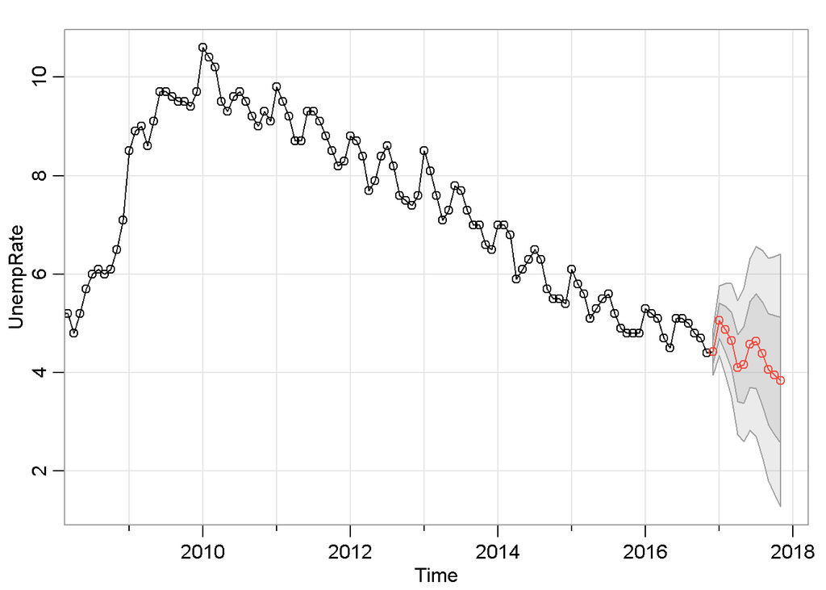

```
## $pred
##           Jan      Feb      Mar      Apr      May      Jun      Jul      Aug
## 2016
## 2017 5.052758 4.877218 4.649057 4.095737 4.154975 4.570231 4.632799 4.383510
##           Sep      Oct      Nov      Dec
## 2016                            4.421514
## 2017 4.062609 3.944758 3.838447
##
## $se
##            Jan       Feb       Mar       Apr       May       Jun       Jul
## 2016
## 2017 0.3516689 0.4670626 0.5766148 0.6811037 0.7804349 0.8747939 0.9644385
##            Aug       Sep       Oct       Nov       Dec
## 2016                                         0.2357858
## 2017 1.0496799 1.1308479 1.2082705 1.2822619
```

```r
sarima.for(UnempRate, n.ahead = 12, p=2,d= 1,q= 1,P= 0,D= 1,Q= 1,S= 12)
```

EJERCICIOS CAPITULO 4

4.10 Los niveles de concentración de sal que se sabe que ocurrieron sobre las filas, correspondientes a los niveles de temperatura promedio para los datos de la ciencia del suelo considerados en la Figura 1.18 y la Figura 1.19, están en salt y saltemp . Trace la serie y luego identifique las frecuencias dominantes realizando análisis espectrales separados en las dos series. Incluya intervalos de confianza para las frecuencias dominantes e interprete sus hallazgos

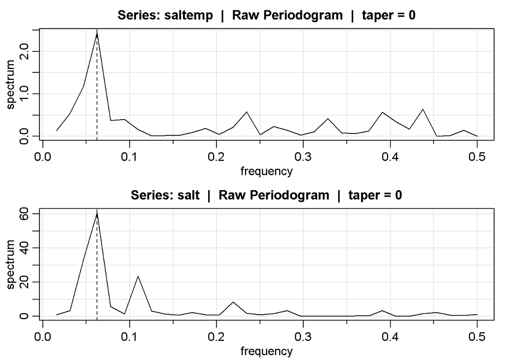

```r
data(saltemp)
par(mfrow=c(2,1)) # for CIs, remove log="no" below
mvspec(saltemp, taper=0, log="no")
abline(v=1/16, lty="dashed")
mvspec(salt, taper=0, log="no")
abline(v=1/16, lty="dashed")
```

un procedimiento de estimación espectral no paramétrico el kernel d daniel perilograma, es una fucnion en un espacio de frecuencias, lo que ayuda es a identificar frecuencias importantes, identificar el factor, cada tanto ocurre un factor ciclico o esatcional

4.15 Repita el problema 4.10 utilizando un procedimiento de estimación espectral no paramétrico. Además de discutir sus hallazgos en detalle, comente su elección de una estimación espectral con respecto al suavizado y la disminución gradual.

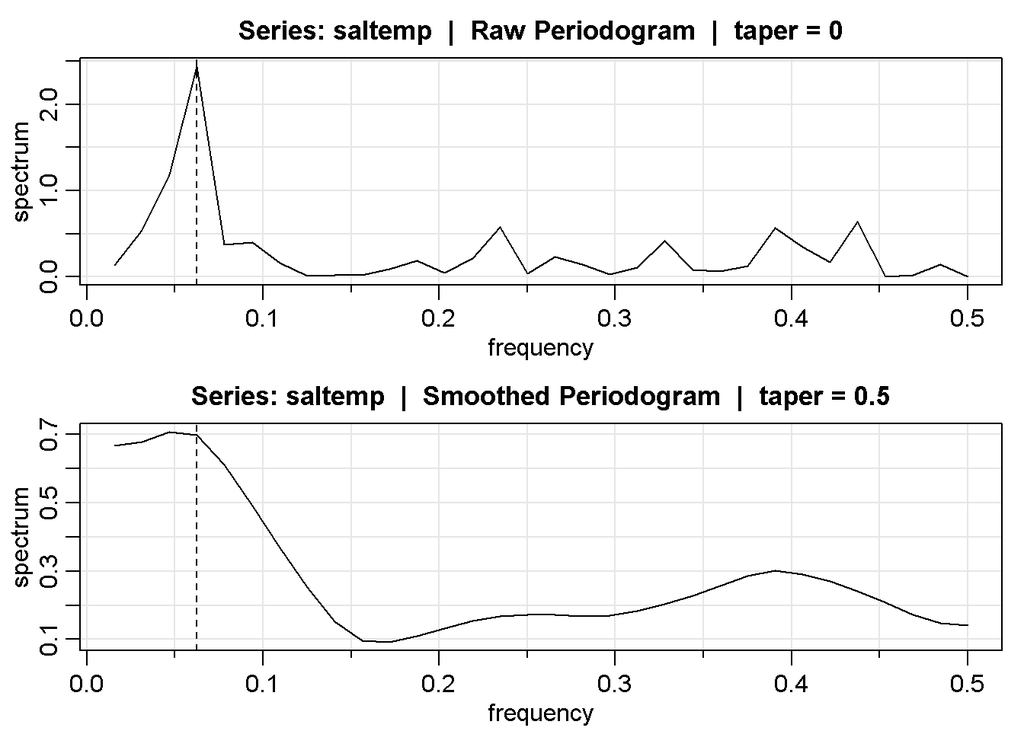

```r
data("saltemp")
par(mfrow=c(2,1))
mvspec(saltemp, taper=0)
abline(v=1/16, lty="dashed")
mvspec(saltemp, spans=c(7,7), log="no", taper=0.5)
abline(v=1/16, lty="dashed")
```

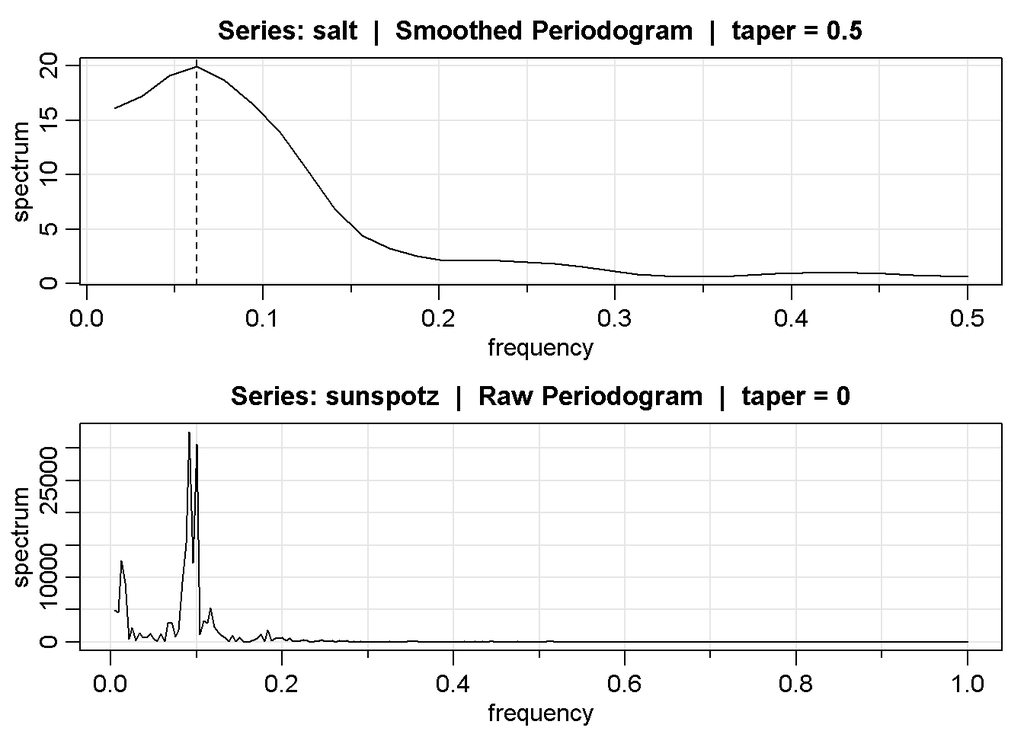

```r
salt.per = mvspec(salt, spans=c(7,7), log="no", taper=.5)
abline(v=1/16, lty="dashed")#kernell("daniell",4)


mvspec(sunspotz, log = "no")
```

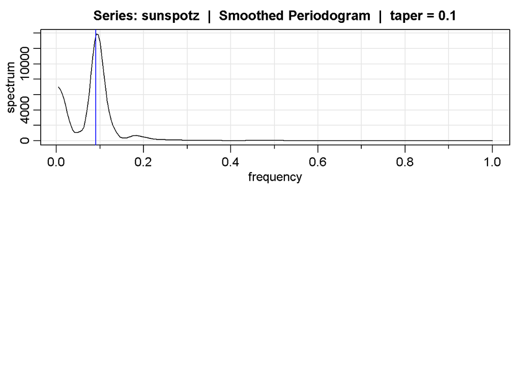

```r
mvspec(sunspotz, spans = c(7,7), taper = 0.1, log = "no")
abline(v= 1/11, col="blue")
```

Por problema 4.9 se tiene lo anterior, entonces se continua con

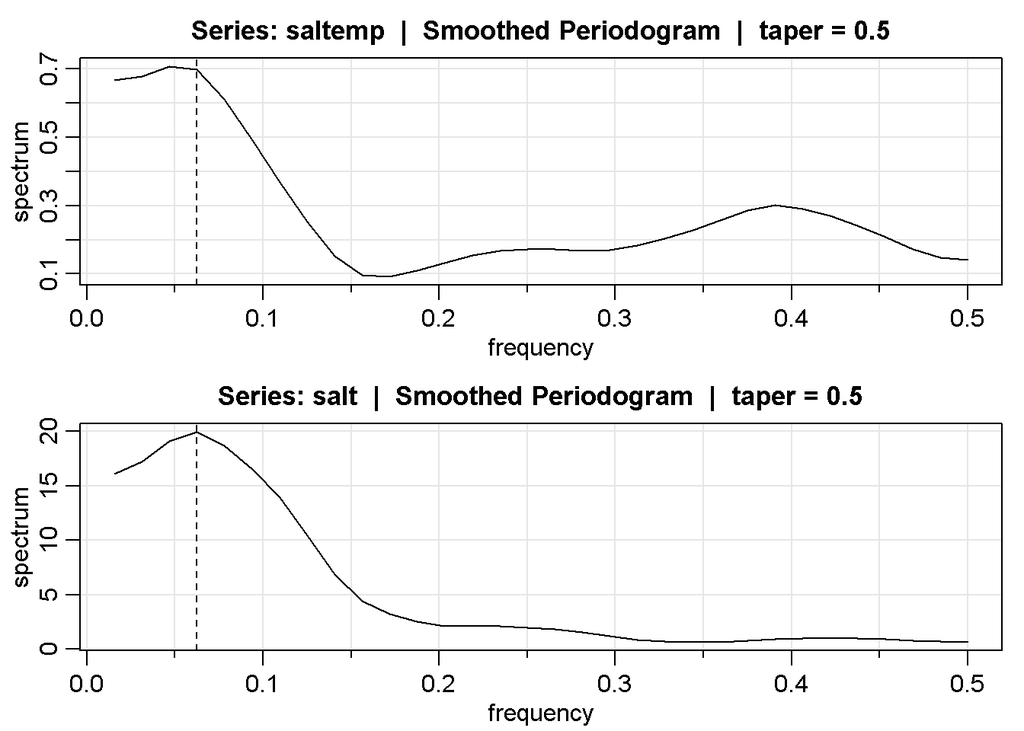

```r
par(mfrow=c(2,1))
mvspec(saltemp, spans=c(7,7), log="no", taper=.5)
abline(v=1/16, lty="dashed")
salt.per = mvspec(salt, spans=c(7,7), log="no", taper=.5)
abline(v=1/16, lty="dashed")
```